# Covariance of Sptial-temporal data

2023-10-27

# 1 Some assumptions

First, let’s define the observations grid as follows:

- Sample size i = 1… N
- Temporal grid t = 1…T
- Spatial grid: two dimensional $\mathbf{s} = (s_1, s_2)$, where $s1, s2 \in [1, 2, ..., S]$. I will hereafter denote the collection of all spatial ind as $\mathscr{S}$.
- Assume for now data is collected on a regular grid. For simplicity, we further set $T=S=10$, making 100 spatial coordinates and 10 temporal measurements for every subject at every spatial coordinate.

In this case, the outcome $Y_i(\mathbf{s}, t)$ is indexed by three variables: $s_1, s_2$ and t. It can be broken down in to a fixed process and a random (subject-level) process (ignoring random error process for now):

$$Y_i(s_1, s_2, t) = f_0(s_1, s_2, t) +
b_i(s_1, s_2, t)$$

For simplicity, let’s assume that the randon effect of space $\mathbf{s}$ and time $t$ is factorizable, but the random effect between different dimensions in space (between $s_1$ and $s_2$) are not factorizable. The random effect can then be written as:

$$b_i(s_1, s_2, t) = \xi_{i1}\phi_1(s_1,
s_2)+\xi_{i2}\phi_2(t)$$

# 2 Covariance matrix

What we are trying to do here is calculate the covariance between $Y$ at each pairs of combination of $(s_1, s_2, t)$, as follows:

$$Cov(Y(s_1, s_2, t), Y(s_1',
s_2', t')) = \frac{1}{N} \sum_{i=1}^N [Y_i(s_1, s_2,
t)-\bar{Y}(s_1, s_2, t)] [Y_i(s_1', s_2',
t')-\bar{Y}(s_1', s_2', t')]$$

This measure would be a function of six variables: $s_1, s_2, t, s_1', s_2'$ and $t'$. a 6-dimensional function is difficult to present using traditional methods like heatmap. I am going to try to explain why it is the case below.

For simplicity, let’s first assume we are conditioning on a specific time point $t^*$ and only thinking about covariance between spatial coordinates:

$$Cov(Y(s_1, s_2, t^*), Y(s_1',
s_2', t^*))$$

The two points can be any pair of points in the 2D surface $\mathscr{S}$ below:

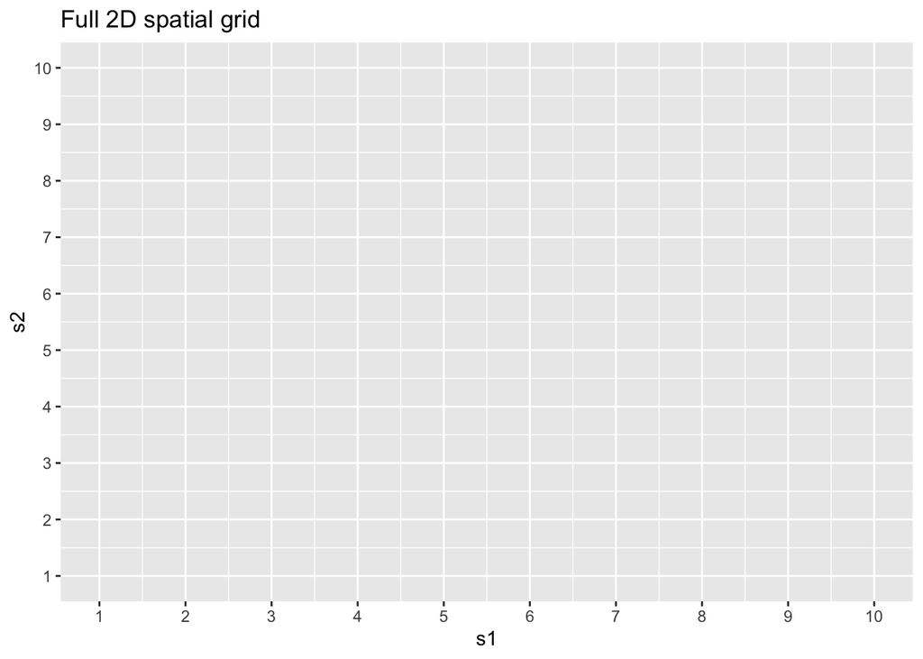

```r
sp_grid <- expand.grid(s1=1:10, s2=1:10)
ggplot(sp_grid, aes(x=s1, y=s2))+
  scale_x_continuous(breaks = 1:10)+
  scale_y_continuous(breaks = 1:10)+
  labs(title = c("Full 2D spatial grid"))
```

And then we try to calculate covariance between measures taken at every pair of points, which are written out as below:

$$\begin{aligned}
& Cov(Y(1, 1, t^*), Y(1, 1, t^*)) \\
& Cov(Y(1, 1, t^*), Y(2, 1, t^*)) \\
& ...\\
& Cov(Y(1, 1, t^*), Y(10, 1, t^*)) \\
& \\
& Cov(Y(1, 1, t^*), Y(1, 2, t^*)) \\
& Cov(Y(1, 1, t^*), Y(2, 2, t^*)) \\
& ... \\
& Cov(Y(1, 1, t^*), Y(10, 2, t^*)) \\
& ... \\
& ... \\
& Cov(Y(10, 10, t^*), Y(10, 10, t^*)) \\
\end{aligned}$$

As you can see, both $s_1, s_2, s_1',s_2'$ varies from 1:10. Therefore, we will have $10\times10\times10\times10$ values, not the 100 points in the original space grid.

If we flatten the covariances on to a 2D surface by the coordinates of point 1 and point 2, both axis will be index by the full coordinate $(s_1, s_2)$, instead of the single space dimension, just like below:

(Apologize for the small font size. I really don’t know how to make this prettier.)

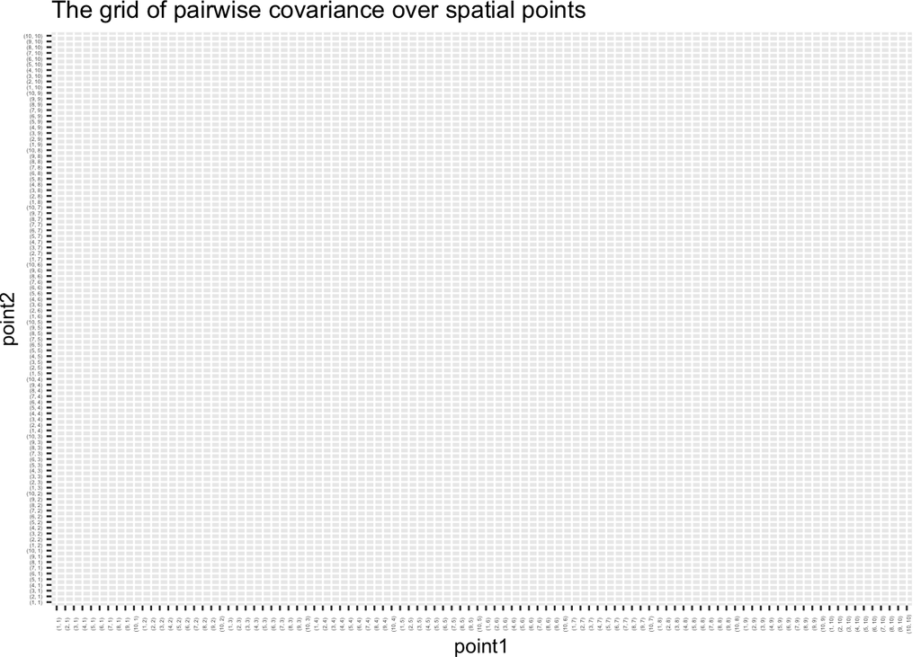

```r
sp_grid <- sp_grid %>%
  mutate(coord = paste0("(", s1, ", ", s2, ")"))

cor_grid <- expand.grid(point1 = sp_grid$coord, point2 = sp_grid$coord)

cor_grid %>%
  ggplot(aes(x=point1, y=point2))+
  theme(axis.text.x = element_text(size = 3, angle = 90),
        axis.text.y = element_text(size = 3),
        plot.margin = margin(0, 5, 0, 0, "pt"))+
  labs(title = "The grid of pairwise covariance over spatial points")
```

This is also why we saw the little $10\times 10$ squares in the covariance heatmap in our meeting yesterday. This is because each single space dimension $s_1$ or $s_2$ alters cyclically every 10 measurements. Take point1 axis as an example: the first ten points are (1,1) to (10, 1), then the next 10 points (1,2) to (10, 2), and so on.

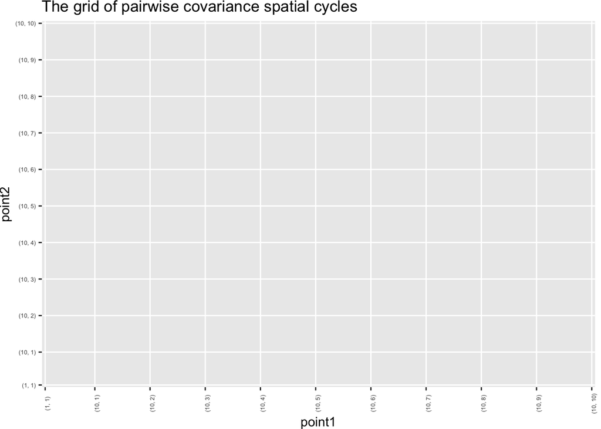

```r
end_cyc <- grep("\\(10, ", cor_grid$point1, value =T)
end_cyc <- c("(1, 1)", end_cyc)

cor_grid %>%
  ggplot(aes(x=point1, y=point2))+
  scale_x_discrete(breaks=end_cyc)+
  scale_y_discrete(breaks=end_cyc)+
  theme(axis.text.x = element_text(size = 5, angle = 90),
        axis.text.y = element_text(size = 5),
        plot.margin = margin(0, 5, 0, 0, "pt"))+
  labs(title = "The grid of pairwise covariance spatial cycles")
```